# reproducibleresearch_ex1

## Activity Data Set

The data in this analysis is data from a personal activity monitoring device. It consists of the date, the amount of steps and the time interval in which the steps were measured. In the following step the data is loaded and the date is transformed to date format from a character format.

```r
df <- read.table("./activity/activity.csv",sep=",",na.strings="NA",header = TRUE)
df$date <- as.Date(df$date, "%Y-%m-%d")
```

## Total number of steps taken each day

The following code calculates the total number of steps for each day. The plot shows the result.

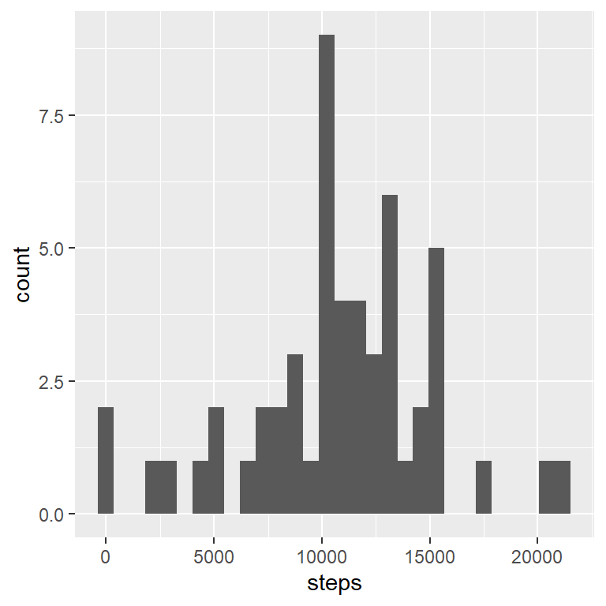

```r
total_steps <- aggregate(steps~date,data=df,sum)

ggplot(total_steps)+
  geom_histogram(aes(steps))
```

## Mean and median steps each day

The mean and median steps for each day are calculated.

```r
mean_steps <- aggregate(steps~date,data=df,mean)
mean_steps
```

```
##          date      steps
## 1  2012-10-02  0.4375000
## 2  2012-10-03 39.4166667
## 3  2012-10-04 42.0694444
## 4  2012-10-05 46.1597222
## 5  2012-10-06 53.5416667
## 6  2012-10-07 38.2465278
## 7  2012-10-09 44.4826389
## 8  2012-10-10 34.3750000
## 9  2012-10-11 35.7777778
## 10 2012-10-12 60.3541667
## 11 2012-10-13 43.1458333
## 12 2012-10-14 52.4236111
## 13 2012-10-15 35.2048611
## 14 2012-10-16 52.3750000
```

[output cut: 39 more lines]

```r
median_steps <- aggregate(steps~date,data=df,median)
median_steps
```

```
##          date steps
## 1  2012-10-02     0
## 2  2012-10-03     0
## 3  2012-10-04     0
## 4  2012-10-05     0
## 5  2012-10-06     0
## 6  2012-10-07     0
## 7  2012-10-09     0
## 8  2012-10-10     0
## 9  2012-10-11     0
## 10 2012-10-12     0
## 11 2012-10-13     0
## 12 2012-10-14     0
## 13 2012-10-15     0
## 14 2012-10-16     0
```

[output cut: 39 more lines]

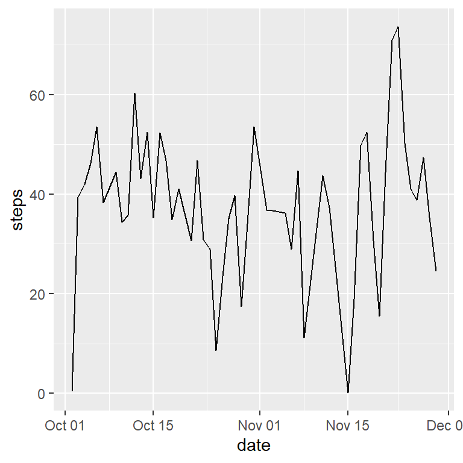

```r
ggplot(mean_steps)+
  geom_line(aes(date,steps))
```

## Daily activity

The average daily activity pattern is obtained by calculating the average for each interval across all days. The maximum amount of steps are taken from this calculation.

```r
mean_steps_by_interval <- aggregate(steps~interval,data=df,mean)
mean_steps_by_interval$interval[which.max(mean_steps_by_interval$steps)]
```

```
## [1] 835
```

## Imputing missing data

The missing values in the steps variable are replace by the average steps for the concerning time interval.

```r
sum(complete.cases(df))
```

```
## [1] 15264
```

```r
df_i <- df
na_pos <- which(is.na(df_i$steps))
df_i$steps[na_pos] <- mean_steps_by_interval$steps[match(df_i$interval[na_pos],mean_steps_by_interval$interval)]
```

## Total number of steps with imputed data

With the imputed data, the total steps are calculated and plotted.

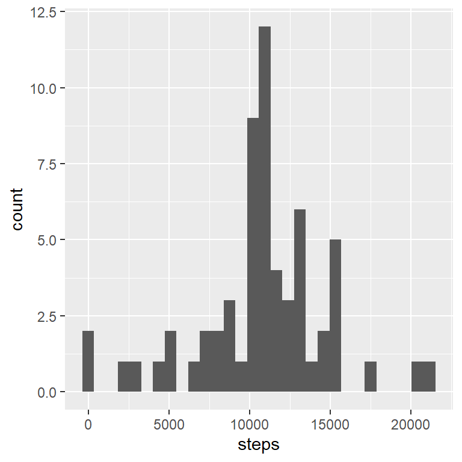

```r
total_steps_i <- aggregate(steps~date,data=df_i,sum)

ggplot(total_steps_i)+
  geom_histogram(aes(steps))
```

## Mean number of steps with imputed data

The mean and median steps on each date is calculated with the imputed data set as well.

```r
mean_steps <- aggregate(steps~date,data=df_i,mean)
mean_steps
```

```
##          date      steps
## 1  2012-10-01 37.3825996
## 2  2012-10-02  0.4375000
## 3  2012-10-03 39.4166667
## 4  2012-10-04 42.0694444
## 5  2012-10-05 46.1597222
## 6  2012-10-06 53.5416667
## 7  2012-10-07 38.2465278
## 8  2012-10-08 37.3825996
## 9  2012-10-09 44.4826389
## 10 2012-10-10 34.3750000
## 11 2012-10-11 35.7777778
## 12 2012-10-12 60.3541667
## 13 2012-10-13 43.1458333
## 14 2012-10-14 52.4236111
```

[output cut: 47 more lines]

```r
median_steps <- aggregate(steps~date,data=df_i,median)
median_steps
```

```
##          date    steps
## 1  2012-10-01 34.11321
## 2  2012-10-02  0.00000
## 3  2012-10-03  0.00000
## 4  2012-10-04  0.00000
## 5  2012-10-05  0.00000
## 6  2012-10-06  0.00000
## 7  2012-10-07  0.00000
## 8  2012-10-08 34.11321
## 9  2012-10-09  0.00000
## 10 2012-10-10  0.00000
## 11 2012-10-11  0.00000
## 12 2012-10-12  0.00000
## 13 2012-10-13  0.00000
## 14 2012-10-14  0.00000
```

[output cut: 47 more lines]

### Comparison the averga steps across weekdays and weekends

To the imputed data set a new column is added, indicating if the date is a weekday or not. Using this column, the mean steps across time intervals and the categories weekday/weekend are calculated and plotted.

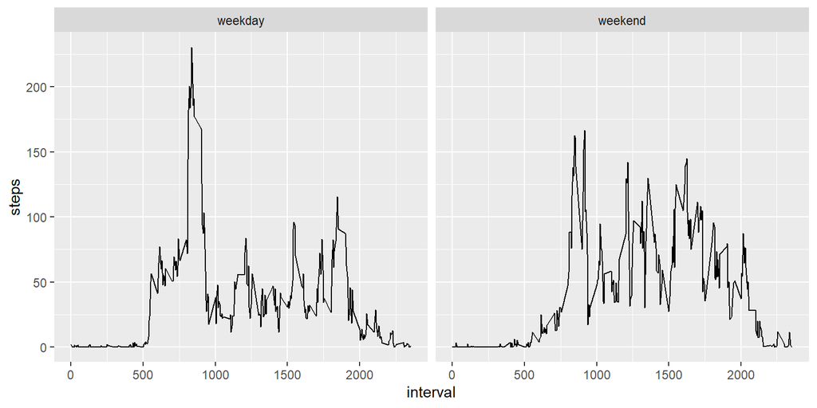

```r
df_i$days <- weekdays(df_i$date) %in% c("Saturday","Sunday")
df_i$days <- c("weekend","weekday")[match(df_i$days,c(TRUE,FALSE))]
df_i$days <- factor(df_i$days)

mean_per_days <- aggregate(steps~days+interval,data=df_i,mean)

ggplot(mean_per_days)+
  geom_line(aes(x=interval,y=steps))+
  facet_wrap(~days)
```